# Reproducible Research: Peer Assessment 1

load the required libraries

```r
library(tidyverse)
library(lubridate)
library(stats)
```

## Loading and preprocessing the data

```r
url <- "https://d396qusza40orc.cloudfront.net/repdata%2Fdata%2Factivity.zip"
temp <- tempfile()
download.file(url, temp)
data <- read.table(unz(temp, "activity.csv"), sep =",", header = TRUE )
unlink(temp)
data <- as_tibble(data)
data <- mutate(data,
                day_of_week = wday(date),
                weekday_weekend = if_else(day_of_week == 1 | day_of_week == 7, "weekend", "weekday")
               )
data$weekday_weekend <- as.factor(data$weekday_weekend)
data_group_1 <- group_by(data, date) %>% summarise(steps = sum(steps))
head(data)
```

```
## # A tibble: 6 x 5
##   steps date       interval day_of_week weekday_weekend
##   <int> <fct>         <int>       <dbl> <fct>
## 1    NA 2012-10-01        0           2 weekday
## 2    NA 2012-10-01        5           2 weekday
## 3    NA 2012-10-01       10           2 weekday
## 4    NA 2012-10-01       15           2 weekday
## 5    NA 2012-10-01       20           2 weekday
## 6    NA 2012-10-01       25           2 weekday
```

## What is mean total number of steps taken per day?

Histogram of Daily Steps

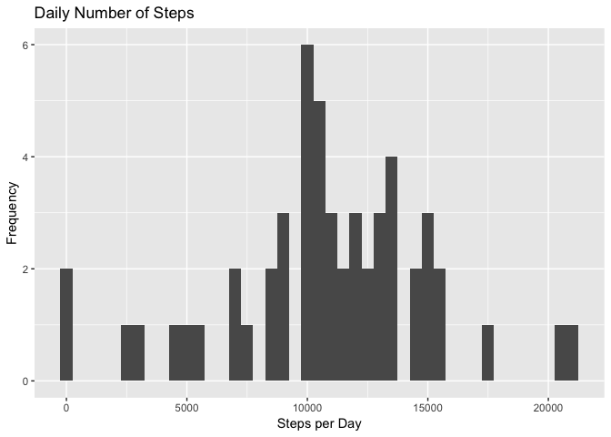

```r
ggplot(data_group_1, aes(x=steps)) +
        geom_histogram(binwidth=500) +
        labs(x = "Steps per Day", y = "Frequency", title = "Daily Number of Steps")
```

```r
summary(data_group_1$steps)
```

```
##    Min. 1st Qu.  Median    Mean 3rd Qu.    Max.    NA's
##      41    8841   10765   10766   13294   21194       8
```

## What is the average daily activity pattern?

This is an graph showing average daily activity at each interval

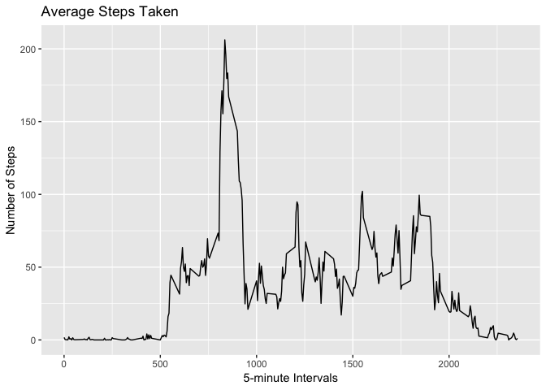

```r
data_group_2 <- group_by(data, interval) %>% summarise(steps = mean(steps, na.rm = TRUE))

ggplot(data=data_group_2, aes(x=interval, y=steps, group=1)) +
        geom_line() +
        labs(x = "5-minute Intervals", y = "Number of Steps", title = "Average Steps Taken")
```

This is the interval with the greatest average activity

```r
data_group_2[which.max(data_group_2$steps),]
```

```
## # A tibble: 1 x 2
##   interval steps
##      <int> <dbl>
## 1      835  206.
```

## Imputing missing values

Find the number of missing values

```r
sum(is.na(data$steps))
```

```
## [1] 2304
```

I use a simple random imputation. For this approach I impute missing values based on the observed data for the variable.

```r
random.imp <- function (a){
        missing <- is.na(a)
        n.missing <- sum(missing)
        a.obs <- a[!missing]
        imputed <- a
        imputed[missing] <- sample (a.obs, n.missing, replace=TRUE)
        return (imputed)
}
df.steps <- random.imp(data$steps)
data$imputed = paste(random.imp(data$steps))
```

Histogram of Steps per Day

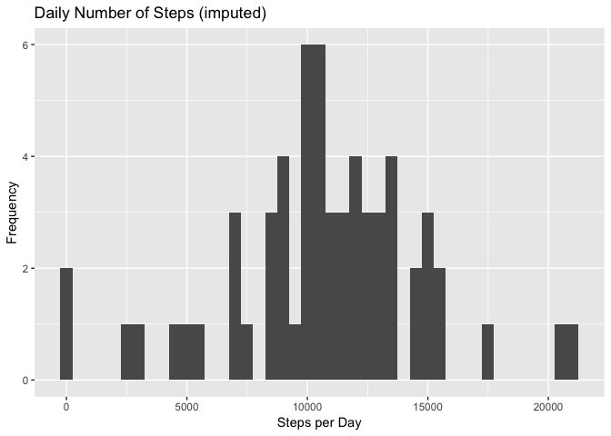

```r
data$imputed <- as.numeric(data$imputed)
data_group_3 <- group_by(data, date) %>% summarise(imputed = sum(imputed))
ggplot(data_group_3, aes(x=imputed)) +
        geom_histogram(binwidth=500) +
        labs(x = "Steps per Day", y = "Frequency", title = "Daily Number of Steps (imputed)")
```

```r
summary(data_group_3$imputed)
```

```
##    Min. 1st Qu.  Median    Mean 3rd Qu.    Max.
##      41    8841   10600   10679   12811   21194
```

## Are there differences in activity patterns between weekdays and weekends?

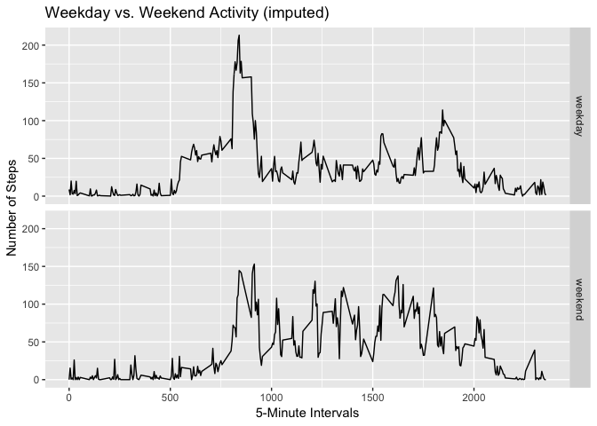

```r
ImputedStepsInterval <- data %>%
        group_by(interval,weekday_weekend) %>%
        summarise(imputed = mean(imputed))

ggplot(ImputedStepsInterval, aes(x=interval, y=imputed)) +
        geom_line() +
        facet_grid(weekday_weekend ~ .) +
        labs(x="5-Minute Intervals", y="Number of Steps", title = "Weekday vs. Weekend Activity (imputed)")
```

During the weekday you see a high maximum number of steps followed by a period of low activity. This differs from the weekend where there appears to be a generally moderate level of sustained activity. Despite having the interval with the highest maximum, the weekday has a lower level of overall activity when compared to the weekend.